# Introduction

This report showcases a preliminary set of possibilities that explore the concept of 'value in the fuel station network' for Z. The definition of 'Value' is given as the importance, worth, or usefulness of something. In the case of a fuel station network, we can break down its *usefulness* to some high level aspects:

- Fuel station locations
  - coverage
- Interactions of fuel stations with the environment
  - With Humans: accessibility, convenience
  - With Other entities (e.g. amenities like cafes, cinema theatres etc.): locale
- Fuel station characteristics
  - Available amenities (e.g. toilets, fuel types, food etc.) - supply
  - Uptake of availabile amenities (i.e. higher scores for amenities that are used more) - where supply meets demand

To make concrete comparisons, we need to further break down these high level aspects into proxy metrics, or quantitative analyses. Metrics provide simplistic, single number comparisons while quantitative analyses generate a more complex picture. For example, we can describe coverage with the following metrics:

| Metric | Definition |
| --- | --- |
| Density | stations per unit area |
| Average spatial separation | typical distance between any two Z stations |
| Station connectivity | # of Z stations within a particular driving radius |

Quantitative analyses of coverage include:

- Nearest neighbours of Z stations
  - The subset with competitor stations as their closest neighbours can be used to identify zones / regions with some degree of poaching by the competitor.
- Using the number of neighbours within a radius to identify the "important" / "centrally" located stations.

## Report Overview

The focus of this report is mainly on the *Coverage* aspect of fuel station value. A natural business question is:

> *Does Z have better coverage than their competitor(s) in Wellington? If so, how?*

The 'how' will involve an analysis of:

- Average spatial separation between two fuel stations
- Station connectivity
- Nearest neighbour fuel stations: same brand or competitor
- Driving accessibility

The main competitor used for comparison is BP. The report will also include details of acquiring and cleaning spatial data.

# Introduction to Spatial data

Spatial data includes geographical information for physical entities in our world. Since we're focusing on man-made entities like fuel stations, the simplest geographical information we require is geolocation. This information can be enriched with attributes that describe local geography - derived from the surrounding environment.

## What spatial data do we need?

We need the following data to calculate the coverage metrics and do the quantitative analyses. There are two key types of data: Base and Points of Interest (POIS). The tools used to get and process the data are described in more detail in the following section.

| Data | Type | Why? | How? |
| --- | --- | --- | --- |
| Geo-tagged fuel stations | POIS | The key spatial entities we're interested in | Open Street Map via Overpass |
| Regional map and street network | Base | To connect the fuel stations via real world streets and roads. | Open Street Map via OSMnx |
| Street network broken up into regular points | Base | For simpler interactions between geography and fuel stations | Open Street Map via Panadana |

[interactive chart not shown]

# Introduction to street network analysis

Having geolocation alone is not very useful beyond plotting points on a map. To know anything useful about the fuel station network, we need the roads connecting the fuel stations. In particular, we'd want to know about the best routes between the fuel stations. With this additional information, we have a trivial network structure: fuel station nodes connected by routes.

## Toy Example: route between Z Kilbirnie and Z Vivian St

The following example looks at the distance and route between two Z stations: Z Kilbernie and Z Vivian St. The red line in the figure is the shortest route that connects the two stations. From the street shapes, you can see that the route is wending it's way around Evans Bay and Basin Reserve, before entering the central city street grid. This route has a distance of 4.6 km - a value that corresponds quite closely to that given by [Google Maps](https://bit.ly/2Mvjr0L).

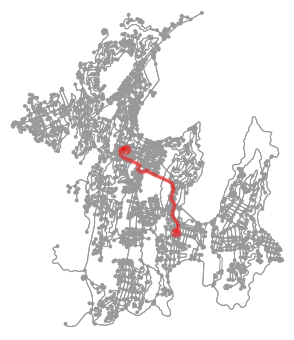

```
Text(0.5,1,'Shortest distance between Z Kilbirnie and Z Vivian St is 4577.443 m')
```

# Analysis: Number of neighbours for Z stations

We can visualise the network structure of the simpler, recast data. Some interesting insights include:

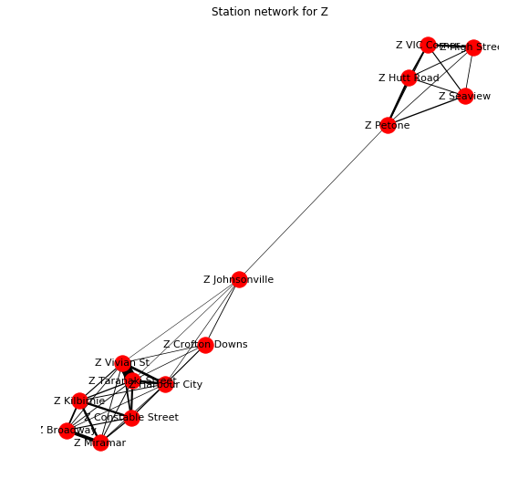

The average degree / connectivity for the Wellington City Z stations is much higher than Lower Hutt. The typical Z station in Wellington City is connected to 2 more Z stations than a typicsl Z station in Lower Hutt.

```
Z stations in Wellington region have an average of 5.71 neighbours
Z stations in Wellington City have an average of 6.5 neighbours
Z stations in Lower Hutt have an average of 4.67 neighbours
```

# Competitor Analysis: Number of neighbours for BP stations

The same network analysis can be done for a competitor. I chose BP, since it *seems* to have a similar coverage to Z in the Wellington region - extending in an arc from Wellington City to the Northern Suburbs to Hutt Valley.

[interactive chart not shown]

The interconnectivity network for BP shares some similar characteristics to the Z network but also has some obvious differences.

- Wellington City and Lower Hutt clusters persist.
- The northern suburbs are a little better connected.
- The Wellington cluster is not as well connected as the Z station network.
- The Lower Hutt cluster for BP is much better connected than Z. BP also has 2 more stations in Lower Hutt compared to Z.

All these points indicate that while Z and BP cover similar areas of Wellington, *Z is better represented in Wellington City while BP dominates in Lower Hutt*. It would be very interesting to see if revenue per station is signficantly different for a Z station in Wellington City vs. Lower Hutt.

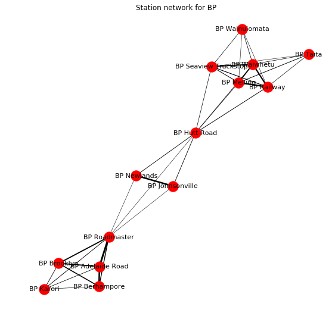

Because the Z station network was a loosely connected network with two strongly connected clusters, we could calculate the average degree per cluster, with little loss of accuracy. The BP network doesn't have the same structure - BP stations are reasonably well connected throughout the Wellington region network.

# Competitor Analysis: Average distance between stations (Z vs. BP)

From this comparison, we can say that Z stations are better spread in the Wellington region compared to BP. We need to exercise some caution however; with only ~13 stations, we don't have much sample size. If we do a more complete analysis for Z, we can get robust statistics by running a hierarchical model for the average inter-station separation across the different types of regions. Until then, we just have to be mindful of how strongly we present this message.

```
Average (mean) inter-station distances:
- Z stations in Wellington are 2.412 km apart on average
- BP stations in Wellington are 3.125 km apart on average
```

# Analysis: Nearest neighbours in joint Z- BP fuel station network

A key characteristic of good coverage is location in relation to other entities - especially competitors. A franchise should ideally be placed close to its own rather than near a competitor. A simple set of comparative analyses that explore the type pf nearest neighbour include:

- Seeing whether Z stations neighbour each other or a competitor
- Which Z stations are in a zone of poaching risk - i.e. their customers might go to a nearby competitor.

For this analysis, we need to generate the shortest distances between all station pairs for *both* Z and BP stations together. The computation is not fast unfortunately so we definitely need to manage this calculation better for a larger dataset. Also, N.B. there is an implicit redundancy in the numbers cited above: some station pairs are each others nearest neighbours.

[output not shown]

# Accessibility analysis

The above analyses only consider the fuel stations and quantify implicit interactions (via road distance) between them. But we get the real benefit of spatial analyses when we consider interactions between the fuel stations and other entities - from humans to other businesses. One type of interaction with general entities is accessibility. Simple accessibility analyses convert the base geography of the region into a point grid, and compute distances between every point and the POIS.

Accessibility is a core analysis in urban planning. Some examples [here](https://www.slideshare.net/DimkaG/transitaccess-27460698). There are even tools which score regions with scores based on accessibility e.g. [WalkScore](https://www.walkscore.com/).

## Accessibility to Z vs. BP

The accessibility heatmaps indicate that both Z and BP have reasonable coverage in the Wellington region. Most of the suburbs seem to be within reasonable (5km) driving distance of a Z / BP fuel station. The heatmaps also highlight some fine-grained details:

- Z has no coverage in Wanuiomata while BP does.
- Z doesn't cover Karori.
- BP doesn't cover the Southern suburbs - specifically those in the Miramar Peninsula (Miramar, Strathmore, Seatoun). Z has excellent coverage in this region.
- Neither Z nor BP cover Eastbourne.
- Z coverage in Lower Hutt is mainly along the main artery of the Hutt: Hutt Road + High Street.
- BP covers Eastern Hutt better in addition to covering along the artery line.

The northern peripheries of the map (e.g. Taita north on the Lower Hutt side and Churton Park north on the Porirua side are not be considered in this analysis as we're missing the complete fuel station data for these areas.

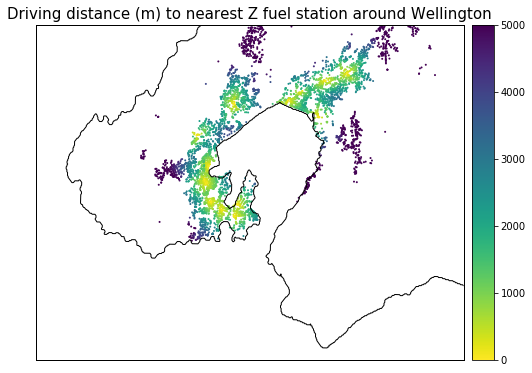

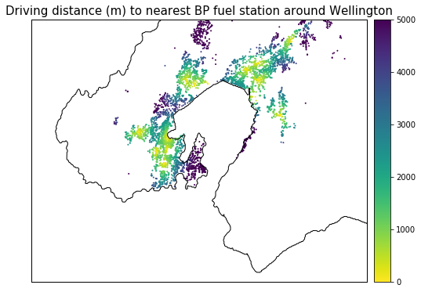

The points made in the above section can be seen more clearly with differences between Z and BP accessibility. Since the accessibility analysis uses the same nodes for both stations, we can calculate a differential value of BP accessibility from Z acessibility: Z accessibibiity - BP accessibility. In other words,

> For any given node, what is the differential distance to a BP station compared to a Z station?

This analysis shows the interplay between Z and BP accessibility within the Wellington region, with accessibility now spanning both positive and negative values. The heatmap colours map positive values to nodes where Z stations are further away than BP; negative colours to nodes where Z stations are closer than BP.

A summary of the differential heatmap colours:

- Red and organge regions indicate better BP coverage (i.e. BP station is closer).
- Blue and green indicate better Z coverage (i.e. Z station is closer).
- Yellow tones indicate good coverage for both stations (i.e. equivalent distance to both Z and BP station).

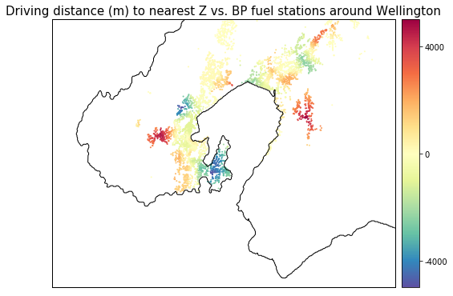

# Conclusions

The key business question to be answered in this report was:

> *Does Z have better coverage than their competitor(s) in Wellington? If so, how?*

Through a variety of different spatial analyses, we can quantify some aspects of this question:

- Z stations are closer together on average, compared to BP.
- Z stations in Wellington City are closely-knit. A Z station in Wellington City has 6.5 Z stations within 10 km. That's 2 more stations than the average for the Lower Hutt sub-network (component).
- BP have more physical stations in Lower Hutt.
- Average accessibility to Z stations is better than BP stations.
- Both Z and BP vie for coverage in the Wellington region - doing well in some areas and poorly in others:
  - Z has exclusive coverage in the Miramar Peninsula and North Western suburbs (Ngaio, Crofton Downs). Petone and the Hutt along the main Hutt Road / High Street artery of Lower Hutt are also better served by Z.
  - BP exclusively covers Wainuiomata and Karori. Parts of the Southern suburbs (like Island Bay) are also better covered by BP.

Given the above findings, we can tentatively answer the business question

> Z stations have better coverage in Wellington compared to BP.

However, this tentative conclusion needs more work to become a substantive one. Suggestions in the following section.

# Future Work

Some immediate follow up work can include:

- A more complete analysis. Since Z is not the only brand of the *Z entity*, we need to include Caltex Stations as well.
- Combining population density with accessibility. Currently, accessibility analysis considers every node to contain the same number of people. This is clearly untrue. A better understanding of the weaknesses in Z's coverage would need to know which high population density nodes have poor access to Z stations.
- Better visualisation of the Pandana heatmaps.

Useful but not as neatly specified work includes:

- Understanding the distribution of available services.
- Statisical modeling:
  - Clustering stations by available services and local geography (e.g. suburban station near many other amenities, isolated suburban station etc).
  - Using spatial flow models (e.g. Retail Model) to predict patronage per fuel station in region; and changes to patronage given poaching by nearby competition. Can consider this a 'No Loyalty' baseline. Useful for comparing with actual patronage data.